# Aligner Performance on Mock Communities Mapped to the Mock Database

Created July 13, 2020

PME

24 July, 2020, 11:40

This notebook gives an overview of the properties of `guppy_aligner`, `minimap2`, and `vsearch` in assigning a well-defined community to a well-defined database. We’re going to subset the positive controls from the CLC experiment, which sequence the zymogen even mock community (DNA standard, item #D6305). As a result, all data below is a best-case scenario.

We are interested specifically in:

1. Sequence retention within an aligner
2. Reproducibility across aligners
3. Accuracy in recreating the community

Including as we increase the threshold for matches. The threshold will be on sequence divergence between the observed and expected sequence for each read/assignment pair.

Sincere apologies for sloppy code in this one.

## Load

```r
libs = c('here', 'magrittr', 'ggplot2', 'reshape2')
for (i in libs) library(i, character.only=TRUE)

fns = here('Scripts', 'Functions') %>%
  list.files(pattern='.R', full.names=TRUE)
for (f in fns) source(f)

path = here('Data', 'Pipeline Results', 'Alignments', 'guppy', 'SAM_Files', 'guppy_aligner_barcode01.sam')
```

```r
# in_clas = "collated_primary_alignment_data.tsv"
# in_uncl = "collated_unclassified_alignment_data.tsv"
in_sam = file.path('Data', 'Pipeline Results', 'Alignments')
in_guppy = file.path(in_sam, 'guppy', 'SAM_Files')
in_vsearch = file.path(in_sam, 'vsearch', 'UC_Files')
in_minimap = file.path(in_sam, 'minimap', 'csv_results')
in_meta = here('Data', 'MinION CLC Barcodes.csv')
in_zymo = here('Data', 'Zymogen Relative Abundances.csv')

in_path = in_guppy
ext = '.sam'
guppy = here(in_path) %>%
  list.files(pattern=ext) %>%
  lapply(function(x) {
    out = here(in_path, x) %>%
      load_sam
    out$aligner = strsplit(x, '_') %>%
      sapply(extract, 1)
    if (grepl('barcode', x)) {
      out$barcode = strsplit(x, 'barcode') %>%
        sapply(extract, 2) %>%
        gsub(ext, '', .)
    } else {
      out$barcode = 'unclassified'
    }
    out$filename = x
    return(out)
  }) %>%
  do.call(rbind, .)

in_path = in_minimap
ext = '.csv'
minimap = here(in_path) %>%
  list.files(pattern=ext) %>%
  lapply(function(x) {
    out = here(in_path, x) %>%
      load_sam
    out$aligner = strsplit(x, '_') %>%
      sapply(extract, 1)
    if (grepl('barcode', x)) {
      out$barcode = strsplit(x, 'barcode') %>%
        sapply(extract, 2) %>%
        gsub(ext, '', .)
    } else {
      out$barcode = 'unclassified'
    }
    out$filename = x
    return(out)
  }) %>%
  do.call(rbind, .)

in_path = in_vsearch
ext = '.uc'
vsearch = here(in_path) %>%
  list.files(pattern=ext) %>%
  lapply(function(x) {
    out = here(in_path, x) %>%
      load_uc
    out$aligner = strsplit(x, '_') %>%
      sapply(extract, 1)
    if (grepl('barcode', x)) {
      out$barcode = strsplit(x, 'barcode') %>%
        sapply(extract, 2) %>%
        gsub(ext, '', .)
    } else {
      out$barcode = 'unclassified'
    }
    out$filename = x
    return(out)
  }) %>%
  do.call(rbind, .)

meta = read.csv(in_meta, stringsAsFactors=FALSE)
names(meta) %<>% tolower
meta$barcode %<>% gsub('BC', '', .)

zymo = read.csv(in_zymo, stringsAsFactors=FALSE)
names(zymo) %<>% tolower
```

Process aligner dataframes

```r
df_ls = list(guppy=guppy,
             minimap=minimap,
             vsearch=vsearch)

# Make spp-level assignments
df_ls %<>% lapply(function(x) {
  x$ref_spp = strsplit(x$ref_id, '_') %>%
    sapply(function(x) paste(x[1:2], collapse='_'))
  x$ref_spp = ifelse(is.na(x$ref_id), NA, x$ref_spp)
  return(x)
})

# rename most columns
keep_cols = c('seq_id', 'barcode', 'ref_id', 'ref_spp', 'bit_flag', 'seq_length', 'divergence', 'score', 'chimeric')
df_ls = lapply(names(df_ls), function(x) {
  tt = df_ls[[x]]
  subkeep = keep_cols[keep_cols %in% names(tt)]
  tt = tt[subkeep]
  names(tt)[-c(1:2)] %<>% paste(x, sep='_')
  return(tt)
})

# merge into a single, wide dataframe
df = df_ls[[1]]
for (i in 2:length(df_ls)) {
  df %<>% merge(df_ls[[i]], by=c('seq_id', 'barcode'), all=TRUE)
}

# add sample info
df %<>% merge(meta[, c('barcode', 'type')], by='barcode', all=TRUE)
```

```r
pos = subset(df, type=='positive')
```

# Aligner Agreement

## Metrics

How do the important alingner diagnostics relate to each other? These are:

1. Sequence length (of the query sequence)
2. Divergence between the query and the reference. This is calculated differently among each aligner. Specifically:
3. minimap2 reports a gap-compressed divergence
4. guppy_aligner reports an “approximate” divergence
5. vsearch reports an exact (basewise) divergence
6. Alignment score (matches - (gaps + mismatches))

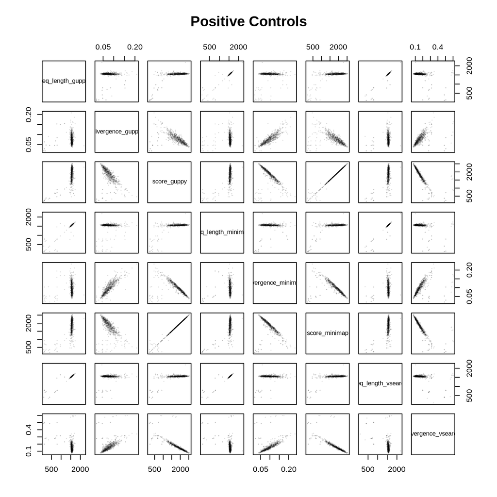

```r
c('seq_length', 'divergence', 'score') %>%
  sapply(function(x) grepl(x, names(df))) %>%
  apply(1, any) %>%
  pos[, .] %>%
  pairs(col='#00000022', cex=0.1, main='Positive Controls')
```

## Assignments

Pairwise disagreements. Do minimap2 and guppy_aligner find the same chimeras?

**Chimeras**

```r
find_disagreement = function(data, value) {
  val = grepl(value, names(data)) %>%
    data[.]
  val_df = apply(val, 1, function(x) any(!is.na(x))) %>%
    val[., ]

  # convert names to numeric ensuring correct factor levels
  lvls = unlist(val_df) %>% unique
  val = val_df %>%
    as.data.frame %>%
    lapply(factor, levels=lvls) %>%
    sapply(as.numeric) %>%
    cor(use='complete.obs')  # correlate

  # calculate disagreement
  val = 1-val
  return(list(disagreement = val, data = val_df))
}

# extract chimeras
find_disagreement(pos, 'chimeric')
```

```
## $disagreement
##                  chimeric_guppy chimeric_minimap
## chimeric_guppy         0.000000         0.857166
## chimeric_minimap       0.857166         0.000000
##
## $data
##                      chimeric_guppy              chimeric_minimap
## 8652   Pseudomonas_aeruginosa_16S_3  Pseudomonas_aeruginosa_16S_1
## 8679        Bacillus_subtilis_16S_8      Bacillus_subtilis_16S_10
## 8685        Bacillus_subtilis_16S_5       Bacillus_subtilis_16S_6
## 8720   Pseudomonas_aeruginosa_16S_3       Bacillus_subtilis_16S_2
## 8725        Bacillus_subtilis_16S_3       Bacillus_subtilis_16S_5
## 8754        Bacillus_subtilis_16S_5       Bacillus_subtilis_16S_5
## 8782        Bacillus_subtilis_16S_8       Bacillus_subtilis_16S_1
## 8794        Bacillus_subtilis_16S_2  Pseudomonas_aeruginosa_16S_1
```

[output cut: 24 more lines]

These disagreements are mostly at the strain level. The aligners flag the same sequences as chimeric. Most of these are within-species “chimeras”.

**Strain assignment** of primary alignments

```r
primaries = subset(pos, bit_flag_guppy < 2048)
find_disagreement(primaries, 'ref_id')$disagreement
```

```
##                ref_id_guppy ref_id_minimap ref_id_vsearch
## ref_id_guppy      0.0000000      0.3312129      0.5334248
## ref_id_minimap    0.3312129      0.0000000      0.5613354
## ref_id_vsearch    0.5334248      0.5613354      0.0000000
```

They all produce quite different results at the strain level. The minion does not give strain-level resolution in metabarcoding.

**Species assignment** of primary alignments

```r
find_disagreement(primaries, 'ref_spp')$disagreement
```

```
##                 ref_spp_guppy ref_spp_minimap ref_spp_vsearch
## ref_spp_guppy      0.00000000      0.01103800      0.06729406
## ref_spp_minimap    0.01103800      0.00000000      0.07805599
## ref_spp_vsearch    0.06729406      0.07805599      0.00000000
```

For the most part, agreement is quite high. Minimap and guppy disagree 1% of the time. Vsearch disagrees 8% of the time. It appears we have *could* have genus-level resolution. We will test this further with a reduced zymogen dataset.

Where are these disagreements?

```r
#' fuzzy column selection
#'
#' @param data data.frame or matrix
#' @param columns vector of characters to match in `colnames(data)` using `grepl()`.
col_subset = function(data, columns) {
  require(magrittr)
  is_col = sapply(columns, function(x) grepl(x, names(data))) %>%
    apply(1, any)
  data %<>% .[is_col]
  return(data)
}

disagrees = col_subset(primaries, 'ref_spp') %>%
  apply(1, function(x) any(x[-1] != x[1]))

disagrees = primaries[disagrees, ] %>%
  col_subset(c('seq_id', 'ref_spp', 'divergence', 'seq_length'))

disagrees
```

|  | seq_id | ref_spp_guppy | seq_length_guppy | divergence_guppy | ref_spp_minimap | seq_length_minimap | divergence_minimap | ref_spp_vsearch | seq_length_vsearch | divergence_vsearch |
| --- | --- | --- | --- | --- | --- | --- | --- | --- | --- | --- |
| 8631 | a128d7ec-b0c5-4d14-9451-efae18f7ea2d | Listeria_monocytogenes | 1598 | 0.1635 | Listeria_monocytogenes | 1598 | 0.1667 | Staphylococcus_aureus | 1598 | 0.602 |
| 8654 | 343193a2-9ca3-4e86-9068-64b16f0c0d6e | Staphylococcus_aureus | 1533 | 0.1125 | Staphylococcus_aureus | 1533 | 0.1745 | Lactobacillus_fermentum | 1533 | 0.230 |
| 8668 | 7b6e20ef-bd1a-4cfd-bb38-ff58bf937c3f | Salmonella_enterica | 1551 | 0.0887 | Salmonella_enterica | 1551 | 0.1241 | Pseudomonas_aeruginosa | 1551 | 0.166 |
| 8680 | fb51a362-9a42-4615-81b6-e055befa1675 | Listeria_monocytogenes | 1540 | 0.0649 | Listeria_monocytogenes | 1540 | 0.0937 | Staphylococcus_aureus | 1540 | 0.114 |
| 8682 | 58c22daa-4369-4236-9c03-d032d4160352 | Staphylococcus_aureus | 1563 | 0.1195 | Staphylococcus_aureus | 1563 | 0.1433 | Lactobacillus_fermentum | 1563 | 0.194 |
| 8709 | 8fa236bd-a854-4f91-a574-cf8636dd956e | Bacillus_subtilis | 1544 | 0.0868 | Bacillus_subtilis | 1544 | 0.0991 | Listeria_monocytogenes | 1544 | 0.128 |
| 8727 | 8780168f-e764-472e-9117-78dabf03b3b2 | Bacillus_subtilis | 1540 | 0.0909 | Bacillus_subtilis | 1540 | 0.1357 | Lactobacillus_fermentum | 1540 | 0.175 |
| 8733 | b1e3323c-9dd4-460a-8bd7-6e1a4c6fed0f | Listeria_monocytogenes | 1546 | 0.0608 | Listeria_monocytogenes | 1546 | 0.0878 | Bacillus_subtilis | 1546 | 0.117 |
| 8786 | e32e4a5e-2b1a-48f5-8b8d-e920f2c247a8 | Enterococcus_faecalis | 1627 | 0.1124 | Enterococcus_faecalis | 1627 | 0.1323 | Saccharomyces_cerevisiae | 1627 | 0.598 |
| 8794 | 3dfc0eff-63c8-4a20-b160-b439c28ee888 | Pseudomonas_aeruginosa | 1458 | 0.1029 | Bacillus_subtilis | 782 | 0.1946 | Pseudomonas_aeruginosa | 1458 | 0.315 |

[output cut: 37 more lines]

Do disagreements correspond with score or sequence length?

Large, red circles are disagreements. Blue circles are agreements.

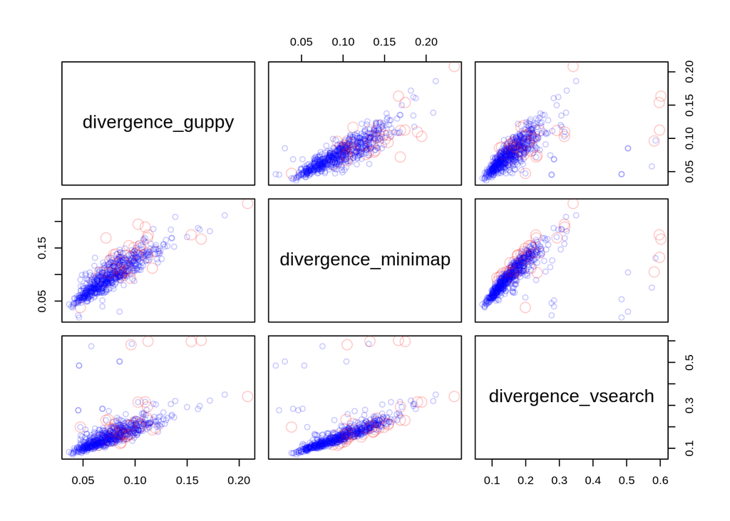

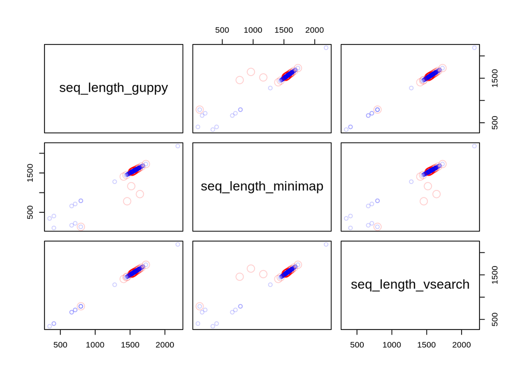

```r
disagree = col_subset(primaries, c('ref_spp')) %>%
  apply(1, function(x) {
    sapply(x, function(y) any(y != x)) %>%
      any
  })

c('divergence', 'seq_length') %>%
  lapply(function(x) col_subset(primaries, x)) %>%
  lapply(pairs, cex=disagree+1, col=adjustcolor(c('blue', 'red'), alpha.f=0.2)[disagree+1])
```

No obvious patterns here. They just disagree sometimes (big and red are disagreements).

# Community Composition of Positive Controls

Let’s look at the composition of the positive controls versus expected at the barcode level. Note that this is a very small subset of the data currently, and so is liable to be noisy.

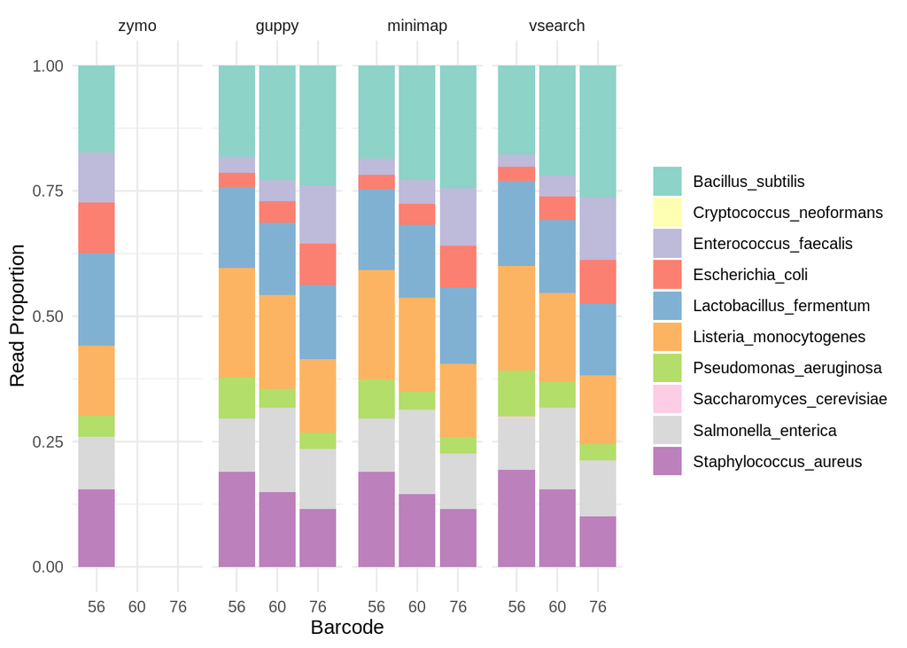

```r
assigns = col_subset(primaries, c('ref_spp', 'barcode'))
bc_reads = with(assigns, tapply(barcode, barcode, length))

tax_reads = melt(assigns, id.vars='barcode') %>%
  aggregate(.[3], ., length)
colnames(tax_reads)[4] = 'count'

split_extract = function(x, split, n) {
  require(magrittr)
  x %<>%
    as.character %>%
    strsplit(split) %>%
    sapply(extract, n)
  return(x)
}

tax_reads$count %<>% divide_by(bc_reads[tax_reads$barcode])
tax_reads$variable %<>%
  split_extract('_', 3)

# add zymo
add_zymo = data.frame(barcode=56,
                      variable='zymo',
                      value=zymo$taxa,
                      count=zymo$abundance)
pltdf = rbind(add_zymo,
              tax_reads)
# pltdf$barcode %<>% as.factor

ggplot(pltdf,
       aes(x=barcode,
           y=count,
           fill=value)) +
  scale_fill_brewer(palette='Set3') +
  facet_wrap(~variable, nrow=1) +
  geom_col() +
  labs(fill=NULL,
       x='Barcode',
       y='Read Proportion') +
  theme_minimal()
```

Generally, this looks pretty good. We see some noise but large bars are large, small bars are small.

Same data, but aggregated across barcodes:

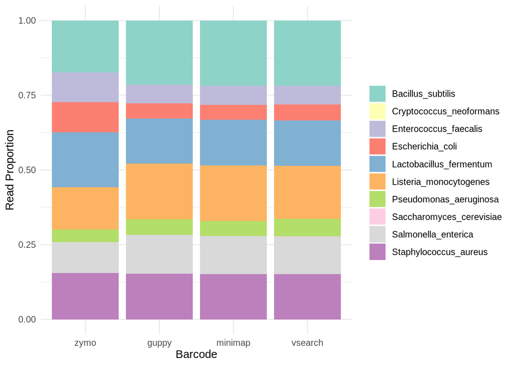

```r
tt = col_subset(primaries, 'ref_spp') %>%
  lapply(function(x) tapply(x, x, length))
tt = names(tt) %>%
  lapply(function(x) {
    out = data.frame(method=x,
                     taxa=names(tt[[x]]),
                     value=tt[[x]])
    return(out)
  }) %>%
  do.call(rbind, .)
reads = tapply(tt$value, tt$method, sum)
tt$proportion = tt$value / reads[tt$method]
tt$value = NULL
tt$method %<>%
  split_extract('_', 3)

add_zymo = data.frame(method='zymo',
                      taxa=zymo$taxa,
                      proportion=zymo$abundance)

pltdf = rbind(add_zymo, tt)
ggplot(pltdf,
       aes(x=method,
           y=proportion,
           fill=taxa)) +
  scale_fill_brewer(palette='Set3') +
  # facet_wrap(~variable, nrow=1) +
  geom_col() +
  labs(fill=NULL,
       x='Barcode',
       y='Read Proportion') +
  theme_minimal()
```

We see some bias in the MinION data, but this is consistent across mappers. It generally is close to expected. Note that we are accepting basically all reads, regardless of % sequence identity with the reference. Therefore, the MinION is not systematically biasing relative abundances at the level of producing sequences. Instead, any bias we observe is due to mismatches with the reference database - i.e. the representation of closely related taxa in the reference database.

*E. faecalis* and *E. coli* seem underrepresented.

Here’s an ordination showing distances. Variances along each axis are the left plot (basically, only axis 1 is important). Here is an ordination of the methods compared to the zymo, to show distance. 0% mapping identitiy threshold.

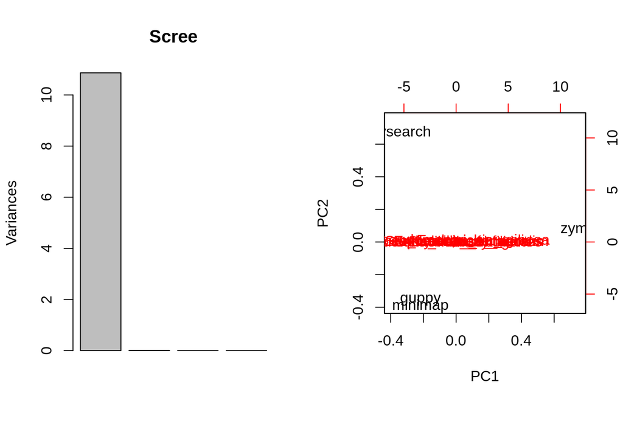

```r
ord_mat = col_subset(primaries, 'ref_spp') %>%
  lapply(function(x) tapply(x, x, length))

ord_mat %<>%
  names %>%
  lapply(function(x) {
    out = data.frame(method=x,
                     taxa=names(ord_mat[[x]]),
                     count=ord_mat[[x]])
    return(out)
  }) %>%
  do.call(rbind, .) %>%
  dcast(method ~ taxa)

ord_mat[is.na(ord_mat)] = 0.5
rownames(ord_mat) = ord_mat$method
ord_mat$method = NULL

add_zymo = zymo[, 'abundance'] %>%
  set_names(zymo[, 'taxa']) %>%
  .[colnames(ord_mat)]

ord_mat %<>% rbind(zymo = add_zymo) %>%
  sweep(., 1, rowSums(.), '/')
ord_mat[ord_mat==0] = 1E-6

rownames(ord_mat) %<>%
  strsplit('_') %>%
  sapply(function(x) x[length(x)])



clr = function(x) {
  n = length(x)
  ll = log(x)
  geomean = exp((1/n)*sum(ll))
  out = log(x/geomean)
  return(out)
}

ord_mat %<>%
  apply(1, clr) %>%
  t

ord = prcomp(ord_mat)

{
  par(mfrow=c(1,2))
  plot(ord, main='Scree')
  biplot(ord)
  par(mfrow=c(1,1))
}
```

Guppy and minimap are basically the same, but disagree with the zymo community about as much as vsearch. Really, they’re all the same.

# Assignment of reads by % sequence divergence threshold

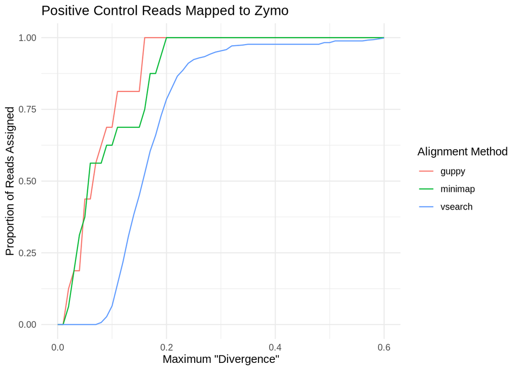

```r
thresholds = seq(0, 0.6, by=0.01)
seq_div = c('guppy', 'minimap', 'vsearch')
seq_div %<>%
  lapply(function(x) col_subset(pos, x)) %>%
  set_names(seq_div) %>%
  lapply(function(x) {
    x %<>% na.omit
    assigned = sapply(thresholds, function(y) {
      sum(col_subset(x, 'divergence') <= y) / nrow(x)
    }) %>%
      set_names(thresholds)
  }) %>%
  do.call(cbind, .) %>%
  cbind(threshold = thresholds) %>%
  melt(id.vars=threshold)

subset(seq_div, Var2 != 'threshold') %>%
  ggplot(aes(x=Var1,
             y=value,
             color=Var2)) +
  # geom_point() +
  geom_path() +
  labs(x='Maximum "Divergence"',
       y='Proportion of Reads Assigned',
       color='Alignment Method',
       title='Positive Control Reads Mapped to Zymo') +
  theme_minimal()
```

At 90% minimum (gap-compressed, approximate) identity, guppy and minimap both align maybe 66% of reads, and around half of reads at 95% identity. Vsearch aligns half of reads at only 83% (absolute) identity.

We can conclude that 80% identity for minimap and 84% for guppy gives high sensitivity, but probably not high specificity.

# Samples - mapped to zymo

Let’s look at the same metric for the samples, which are almost entirely not part of the zymogen database:

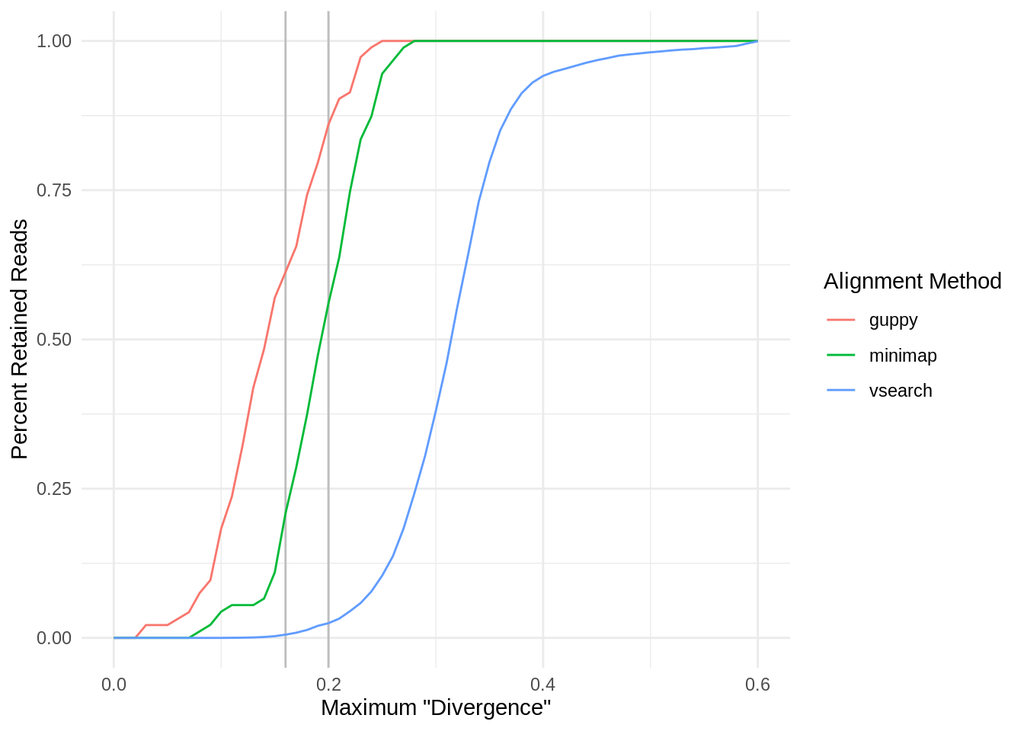

```r
spl = subset(df, type=='sample')
thresholds = seq(0, 0.6, by=0.01)
seq_div = c('guppy', 'minimap', 'vsearch')
seq_div %<>%
  lapply(function(x) col_subset(spl, x)) %>%
  set_names(seq_div) %>%
  lapply(function(x) {
    x %<>% na.omit
    assigned = sapply(thresholds, function(y) {
      sum(col_subset(x, 'divergence') <= y) / nrow(x)
    }) %>%
      set_names(thresholds)
  }) %>%
  do.call(cbind, .) %>%
  cbind(threshold = thresholds) %>%
  melt(id.vars=threshold)

subset(seq_div, Var2 != 'threshold') %>%
  ggplot(aes(x=Var1,
             y=value,
             color=Var2)) +
  geom_vline(aes(xintercept=0.16),
             color='gray') +
  geom_vline(aes(xintercept=0.2),
             color='gray') +
  geom_path() +
  labs(x='Maximum "Divergence"',
       y='Percent Retained Reads',
       color='Alignment Method',
       main='Sample Reads Mapped to Zymo') +
  theme_minimal()
```

For both guppy and minimap, we see a shoulder at around 5% of reads at relatively high divergence (>90%). All map by 75% divergence. Vsearch matches these at 80% identity.

At the their respective maximum sensitivity thresholds, guppy and minimap assign 60% (guppy) and 55% (minimap) of reads to the zymogen mock community. These are probably almost all false positives, meaning a very low classification accuracy.

Looking at the positive controls mapped to a large reference database will clarify this. We will assume that the assignments for the positive controls shown here are correct. They approximately match expected proportions, and we saw very little evidence of barcode switching in the barcoder test.

If we map at 90% identity, how does this change the observed community structure?

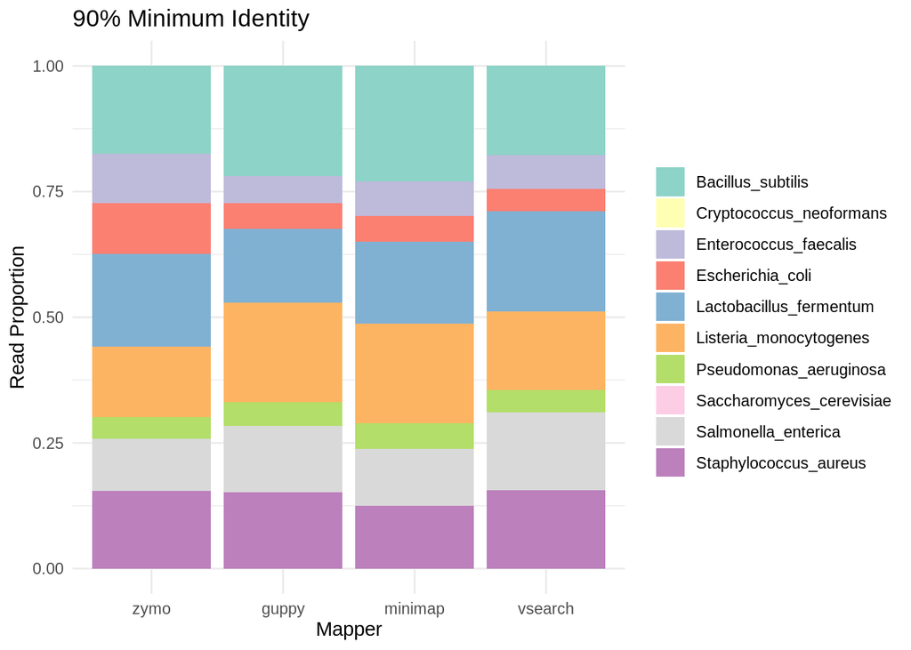

```r
mappers = c('guppy', 'minimap', 'vsearch')

pct_id = 0.90
ss = lapply(mappers, function(x) {
  tt = col_subset(primaries, x)
  passes = col_subset(tt, 'divergence') <= 1-pct_id
  tt = tt[passes, ] %>%
    col_subset('ref_spp')
  tt = tapply(tt[, 1], tt[, 1], length)
  tt = tt/sum(tt)

  tt = data.frame(taxa = names(tt),
                  value = tt)
  return(tt)
}) %>%
  set_names(mappers)

ss = lapply(mappers, function(x) {
  if (nrow(ss[[x]])>0) {
    data.frame(method = x,
               ss[[x]])
  }
}) %>%
  do.call(rbind, .)

add_zymo = data.frame(method='zymo',
                      taxa=zymo$taxa,
                      value=zymo$abundance)
pltdf = rbind(add_zymo,
              ss)
title = (100*pct_id) %>%
  paste0('% Minimum Identity')

ggplot(pltdf,
       aes(x=method,
           y=value,
           fill=taxa)) +
  scale_fill_brewer(palette='Set3') +
  # facet_wrap(~variable, nrow=1) +
  geom_col() +
  labs(fill=NULL,
       x='Mapper',
       y='Read Proportion',
       title=title) +
  theme_minimal()
```

We still recreate the mock community fairly successfully. Noisier due to low sample size.

# Mapping samples to zymogen

We’ll look at what the aligners have found in the samples, when mapping to the zymogen database. Accepting any and all matches gives:

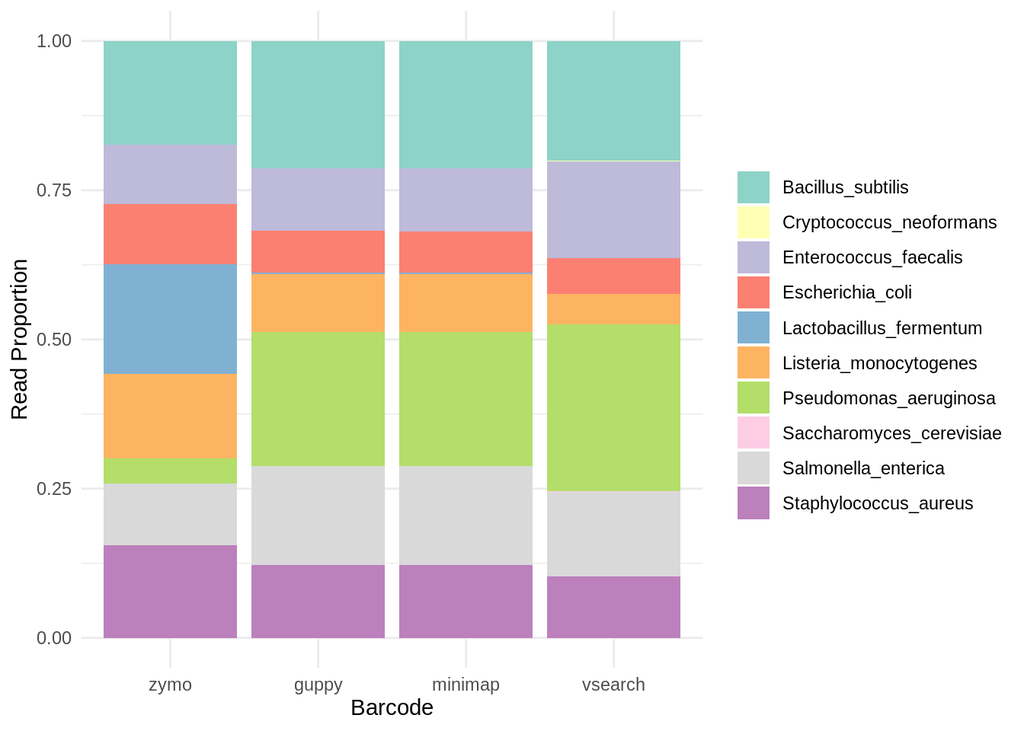

```r
tt = subset(df, type=='sample' & bit_flag_guppy < 256) %>%
  col_subset('ref_spp') %>%
  lapply(function(x) tapply(x, x, length)) %>%
  lapply(function(x) x/sum(x))
tt = names(tt) %>%
  lapply(function(x) {
    out = data.frame(method=x,
                     taxa=names(tt[[x]]),
                     value=tt[[x]])
    return(out)
  }) %>%
  do.call(rbind, .)
tt$method %<>%
  as.character %>%
  strsplit('_') %>%
  sapply(extract, 3)

add_zymo = data.frame(
  method='zymo',
  taxa = zymo$taxa,
  value = zymo$abundance
)

pltdf = add_zymo %>%
  rbind(tt)

ggplot(pltdf,
       aes(x=method,
           y=value,
           fill=taxa)) +
  scale_fill_brewer(palette='Set3') +
  # facet_wrap(~variable, nrow=1) +
  geom_col() +
  labs(fill=NULL,
       x='Barcode',
       y='Read Proportion') +
  theme_minimal()
```

We do not recreate the zymo community in the samples. Lactobacillus is absent, and Pseudomonas is overrepresented.

If we put a threshold at 90% identity:

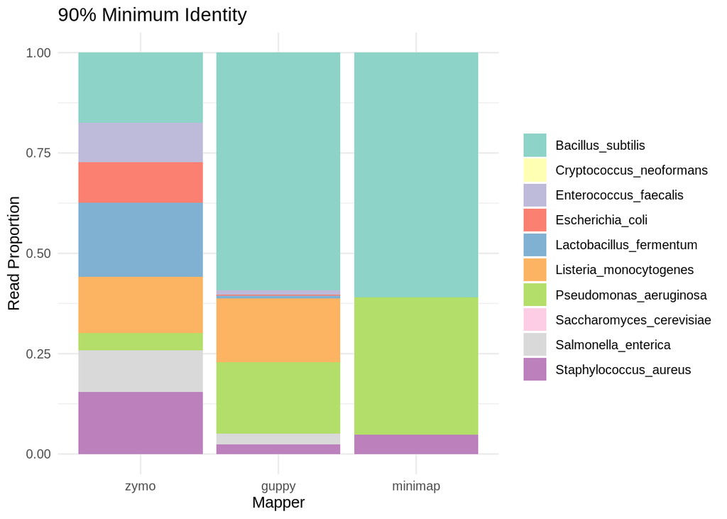

```r
mappers = c('guppy', 'minimap', 'vsearch')

pct_id = 0.90
ss = lapply(mappers, function(x) {
  tt = col_subset(spl, x)
  passes = col_subset(tt, 'divergence') <= 1-pct_id
  tt = tt[passes, ] %>%
    col_subset('ref_spp')
  tt = tapply(tt[, 1], tt[, 1], length)
  tt = tt/sum(tt)

  tt = data.frame(taxa = names(tt),
                  value = tt)
  return(tt)
}) %>%
  set_names(mappers)

ss = lapply(mappers, function(x) {
  if (nrow(ss[[x]])>0) {
    data.frame(method = x,
               ss[[x]])
  }
}) %>%
  do.call(rbind, .)

pltdf = rbind(add_zymo,
              ss)
title = (100*pct_id) %>%
  paste0('% Minimum Identity')

ggplot(pltdf,
       aes(x=method,
           y=value,
           fill=taxa)) +
  scale_fill_brewer(palette='Set3') +
  # facet_wrap(~variable, nrow=1) +
  geom_col() +
  labs(fill=NULL,
       x='Mapper',
       y='Read Proportion',
       title=title) +
  theme_minimal()
```

Well-known soil bacteria dominate. These might be true positives. Minimap seems to do a better job of selecting soil bacteria from the zymogen community, whereas guppy finds a number of mammal-associated bacteria that are likely rare in the soil. Vsearch’s exact identity score doesn’t find anything meeting the threshold.

And at 95% identity:

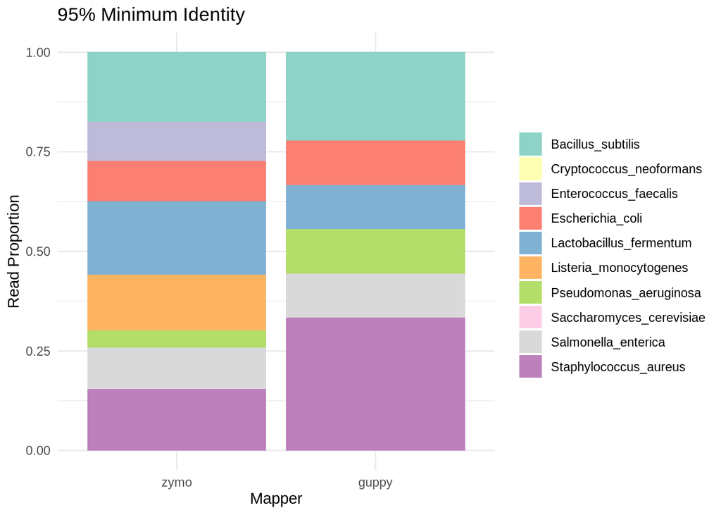

```r
pct_id = 0.95
ss = lapply(mappers, function(x) {
  tt = col_subset(spl, x)
  passes = col_subset(tt, 'divergence') <= 1-pct_id
  tt = tt[passes, ] %>%
    col_subset('ref_spp')
  tt = tapply(tt[, 1], tt[, 1], length)
  tt = tt/sum(tt)

  tt = data.frame(taxa = names(tt),
                  value = tt)
  return(tt)
}) %>%
  set_names(mappers)

ss = lapply(mappers, function(x) {
  if (nrow(ss[[x]])>0) {
    data.frame(method = x,
               ss[[x]])
  }
}) %>%
  do.call(rbind, .)

pltdf = rbind(add_zymo,
              ss)
title = (100*pct_id) %>%
  paste0('% Minimum Identity')

ggplot(pltdf,
       aes(x=method,
           y=value,
           fill=taxa)) +
  scale_fill_brewer(palette='Set3') +
  # facet_wrap(~variable, nrow=1) +
  geom_col() +
  labs(fill=NULL,
       x='Mapper',
       y='Read Proportion',
       title=title) +
  theme_minimal()
```

Many taxa return, and it looks like a bunch of junk.

# Conclusions

First, the minion does not have a strong bias against any of the taxa present in the zymogen mock community; instead, any bias we observe is due to mis-assignments against larger reference databases. This means we can minimize the distance between positive controls mapped to a large reference database and the zymogen composition to parameterize the aligners.

Second, strain-level specificity is not available for barcoding 16S with MinION, using the mapping algorithm. Genus-level sensitivity might be available, but we did not directly test this. A clustering and consensus sequence approach might be more sensitive at the strain level.

Third, all aligners produce fairly similar results when mapped to the positive control - all sequences are known, and are known exactly.

Fourth, minimap might be more discriminatory in settings with less certainty about read identity. This requires verification.

Finally, the reads in the positive controls mapped to the zymogen database can probably be considered correctly assigned, even at 0% minimum identity. The mappers all recreated the community fairly well.

Next steps:

1. Compare this mapping with mapping against:
2. A reduced zymogen database, to test genus-level specificity.
3. Silva, to test species-level specificity.
4. From these results, identify the best-performing aligner and set identity thresholds for mapping.